# **Part A**

```python
import yfinance as yf
import pandas as pd
import numpy as np
import matplotlib.pyplot as plt
from arch import arch_model
from statsmodels.tsa.stattools import adfuller
import os
```

```python
import warnings
warnings.filterwarnings("ignore")
```

## *Downloading Nvidia Stock Data*

```python
ticker = "NVDA"
data = pd.DataFrame(yf.download(ticker, period="5y", interval="1d"))
```

```
[*********************100%***********************]  1 of 1 completed
```

```python
data.info()
```

```
<class 'pandas.core.frame.DataFrame'>
DatetimeIndex: 1255 entries, 2020-07-24 to 2025-07-23
Data columns (total 5 columns):
 #   Column          Non-Null Count  Dtype
---  ------          --------------  -----
 0   (Close, NVDA)   1255 non-null   float64
 1   (High, NVDA)    1255 non-null   float64
 2   (Low, NVDA)     1255 non-null   float64
 3   (Open, NVDA)    1255 non-null   float64
 4   (Volume, NVDA)  1255 non-null   int64
dtypes: float64(4), int64(1)
memory usage: 58.8 KB
```

```python
data = data.droplevel(level=1, axis=1)
data.head()
```

| Price Date | Close | High | Low | Open | Volume |
| --- | --- | --- | --- | --- | --- |
| 2020-07-24 | 10.161009 | 10.330699 | 9.744881 | 9.842558 | 473292000 |
| 2020-07-27 | 10.387261 | 10.407444 | 10.184180 | 10.198633 | 292132000 |
| 2020-07-28 | 10.181939 | 10.347892 | 10.175710 | 10.340168 | 271636000 |
| 2020-07-29 | 10.431119 | 10.481702 | 10.313009 | 10.356615 | 284508000 |
| 2020-07-30 | 10.579128 | 10.588099 | 10.261425 | 10.340913 | 308880000 |

## *Preprocessing Steps*

```python
# Check Log Returns
data['Log_Returns'] = np.log(data['Close']/data['Close'].shift(1))

# Drop missing values
data.dropna(inplace=True)

print(data[['Close', 'Log_Returns']].head())
```

```
Price           Close  Log_Returns
Date
2020-07-27  10.387261     0.022022
2020-07-28  10.181939    -0.019965
2020-07-29  10.431119     0.024178
2020-07-30  10.579128     0.014089
2020-07-31  10.579876     0.000071
```

```python
data.info()
```

```
<class 'pandas.core.frame.DataFrame'>
DatetimeIndex: 1254 entries, 2020-07-27 to 2025-07-23
Data columns (total 6 columns):
 #   Column       Non-Null Count  Dtype
---  ------       --------------  -----
 0   Close        1254 non-null   float64
 1   High         1254 non-null   float64
 2   Low          1254 non-null   float64
 3   Open         1254 non-null   float64
 4   Volume       1254 non-null   int64
 5   Log_Returns  1254 non-null   float64
dtypes: float64(5), int64(1)
memory usage: 68.6 KB
```

## *Plot Close v/s Log Returns*

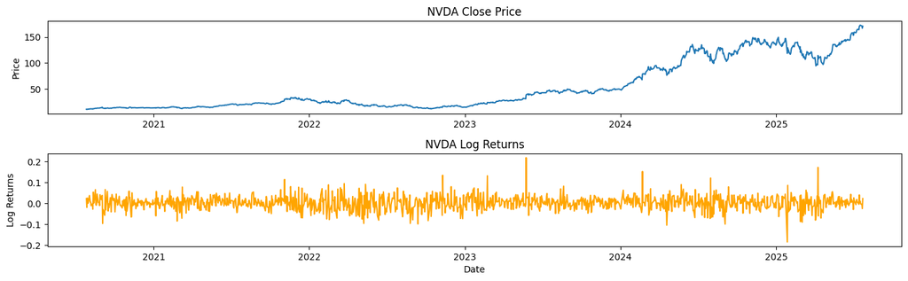

```python
plt.figure(figsize=(14,6))

# Plot original close prices
plt.subplot(3, 1, 1)
plt.plot(data['Close'])
plt.title(f'{ticker} Close Price')
plt.ylabel('Price')

# Plot log returns
plt.subplot(3, 1, 2)
plt.plot(data['Log_Returns'], color='orange')
plt.title(f'{ticker} Log Returns')
plt.ylabel('Log Returns')
plt.xlabel('Date')

plt.tight_layout()
plt.show()
```

Interpretation: We can see that the returns have a somewhat constant mean and do not have any seasonality. However, we can see that the volatility is not constant, with periods of high volatility and periods of low volatility mixed within the data. We can surmise based on this that this series is a great candidate for the GARCH model. The following section will help us in confirming this interpretation.

We can also use the Augmented Dickey-Fuller test to check the stationarity of the data. If the ADF statistic is significant (p-value < 0.05), then we can say that the data is stationary.

```python
adfuller_result = adfuller(data['Close'])
print(f"ADF Statistic: {adfuller_result[0]}")
print(f"p-value: {adfuller_result[1]}")
```

```
ADF Statistic: 1.0124675637012532
p-value: 0.9943957694431481
```

## *ARCH & GARCH Effect*

```python
returns = data['Log_Returns'] * 100
```

```python
arch_func = arch_model(returns, vol='ARCH', p=1)
arch_results = arch_func.fit(update_freq=5)
print(arch_results.summary())
```

```
Iteration:      5,   Func. Count:     27,   Neg. LLF: 3275.907407458456
Optimization terminated successfully    (Exit mode 0)
            Current function value: 3275.907354144463
            Iterations: 7
            Function evaluations: 34
            Gradient evaluations: 7
                      Constant Mean - ARCH Model Results
==============================================================================
Dep. Variable:            Log_Returns   R-squared:                       0.000
Mean Model:             Constant Mean   Adj. R-squared:                  0.000
Vol Model:                       ARCH   Log-Likelihood:               -3275.91
Distribution:                  Normal   AIC:                           6557.81
Method:            Maximum Likelihood   BIC:                           6573.22
                                        No. Observations:                 1254
Date:                Thu, Jul 24 2025   Df Residuals:                     1253
Time:                        13:33:08   Df Model:                            1
                                Mean Model
==========================================================================
                 coef    std err          t      P>|t|    95.0% Conf. Int.
--------------------------------------------------------------------------
mu             0.2430  9.476e-02      2.565  1.033e-02 [5.731e-02,  0.429]
                              Volatility Model
===========================================================================
                 coef    std err          t      P>|t|     95.0% Conf. Int.
---------------------------------------------------------------------------
omega         10.3400      0.846     12.220  2.443e-34    [  8.681, 11.998]
alpha[1]       0.0545  3.821e-02      1.427      0.154 [-2.038e-02,  0.129]
===========================================================================

Covariance estimator: robust
```

Using the summary of the fitting of the ARCH(1) model on our scaled returns, we can see that the alpha[1] coefficient is not significant (p-value is 0.154). Thus, we should check the GARCH model's summary.

```python
garch_func = arch_model(returns, vol='GARCH', p=1, q=1)
garch_results = garch_func.fit(update_freq=5)
print(garch_results.summary())
```

```
Iteration:      5,   Func. Count:     33,   Neg. LLF: 3270.591751241234
Iteration:     10,   Func. Count:     62,   Neg. LLF: 3253.66587808229
Optimization terminated successfully    (Exit mode 0)
            Current function value: 3253.66587808229
            Iterations: 11
            Function evaluations: 66
            Gradient evaluations: 11
                     Constant Mean - GARCH Model Results
==============================================================================
Dep. Variable:            Log_Returns   R-squared:                       0.000
Mean Model:             Constant Mean   Adj. R-squared:                  0.000
Vol Model:                      GARCH   Log-Likelihood:               -3253.67
Distribution:                  Normal   AIC:                           6515.33
Method:            Maximum Likelihood   BIC:                           6535.87
                                        No. Observations:                 1254
Date:                Thu, Jul 24 2025   Df Residuals:                     1253
Time:                        13:33:08   Df Model:                            1
                               Mean Model
========================================================================
                 coef    std err          t      P>|t|  95.0% Conf. Int.
------------------------------------------------------------------------
mu             0.3088  9.184e-02      3.363  7.714e-04 [  0.129,  0.489]
                             Volatility Model
==========================================================================
                 coef    std err          t      P>|t|    95.0% Conf. Int.
--------------------------------------------------------------------------
omega          0.7529      0.464      1.621      0.105   [ -0.157,  1.663]
alpha[1]       0.0771  3.394e-02      2.272  2.307e-02 [1.060e-02,  0.144]
beta[1]        0.8575  5.762e-02     14.883  4.219e-50   [  0.745,  0.970]
==========================================================================

Covariance estimator: robust
```

Based on the summary of the fitting of the GARCH(1, 1) model on our scaled returns, we can see that both alpha[1] and beta[1] are significant (p-values are less than 0.05). Hence, we can confidently reject the null hypothesis.

```python
conditional_vol = garch_results.conditional_volatility
forecast = garch_results.forecast(horizon=90)
forecasted_vol = np.sqrt(forecast.variance.iloc[-1])
```

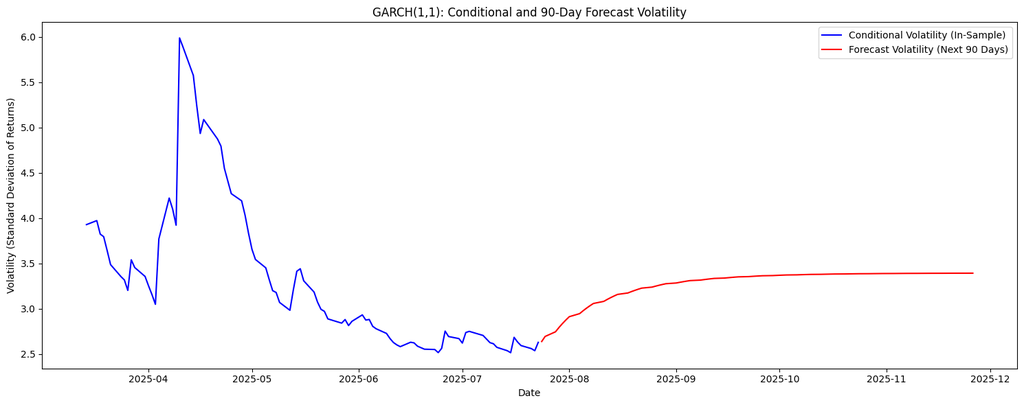

```python
# Create index for forecast days (business days)
forecast_index = pd.date_range(start=conditional_vol.index[-1] + pd.Timedelta(days=1), periods=90, freq='B')

# Plot
plt.figure(figsize=(15,6))
plt.plot(conditional_vol.index[-90:], conditional_vol[-90:], label='Conditional Volatility (In-Sample)', color='blue')
plt.plot(forecast_index, forecasted_vol, label='Forecast Volatility (Next 90 Days)', color='red')
plt.title('GARCH(1,1): Conditional and 90-Day Forecast Volatility')
plt.xlabel('Date')
plt.ylabel('Volatility (Standard Deviation of Returns)')
plt.legend()
plt.tight_layout()
plt.show()
```

# **Part B**

```python
from statsmodels.tsa.api import VAR
from statsmodels.tsa.stattools import adfuller
from statsmodels.tsa.vector_ar.vecm import coint_johansen, VECM
```

```python
BASE = os.getcwd()

DATASETS_DIR = os.path.join(BASE, 'datasets')
DATASET_FILE = "CMO-Historical-Data-Monthly.xlsx"
DATASET_PATH = os.path.join(DATASETS_DIR, DATASET_FILE)
```

```python
data = pd.read_excel(DATASET_PATH, sheet_name='Monthly Prices', skiprows=6)
```

```python
data.head()
```

|  | Unnamed: 0 | CRUDE_PETRO | CRUDE_BRENT | CRUDE_DUBAI | CRUDE_WTI | COAL_AUS | COAL_SAFRICA | NGAS_US | NGAS_EUR | NGAS_JP | ... | ALUMINUM | IRON_ORE | COPPER | LEAD | Tin | NICKEL | Zinc | GOLD | PLATINUM | SILVER |
| --- | --- | --- | --- | --- | --- | --- | --- | --- | --- | --- | --- | --- | --- | --- | --- | --- | --- | --- | --- | --- | --- |
| 0 | 1960M01 | 1.63 | 1.63 | 1.63 | … | … | … | 0.14 | 0.404774 | … | ... | 511.471832 | 11.42 | 715.40 | 206.1 | 2180.4 | 1631.0 | 260.8 | 35.27 | 83.5 | 0.9137 |
| 1 | 1960M02 | 1.63 | 1.63 | 1.63 | … | … | … | 0.14 | 0.404774 | … | ... | 511.471832 | 11.42 | 728.19 | 203.7 | 2180.4 | 1631.0 | 244.9 | 35.27 | 83.5 | 0.9137 |
| 2 | 1960M03 | 1.63 | 1.63 | 1.63 | … | … | … | 0.14 | 0.404774 | … | ... | 511.471832 | 11.42 | 684.94 | 210.3 | 2173.8 | 1631.0 | 248.7 | 35.27 | 83.5 | 0.9137 |
| 3 | 1960M04 | 1.63 | 1.63 | 1.63 | … | … | … | 0.14 | 0.404774 | … | ... | 511.471832 | 11.42 | 723.11 | 213.6 | 2178.2 | 1631.0 | 254.6 | 35.27 | 83.5 | 0.9137 |
| 4 | 1960M05 | 1.63 | 1.63 | 1.63 | … | … | … | 0.14 | 0.404774 | … | ... | 511.471832 | 11.42 | 684.75 | 213.4 | 2162.7 | 1631.0 | 253.8 | 35.27 | 83.5 | 0.9137 |

5 rows × 72 columns

```python
data.info()
```

```
<class 'pandas.core.frame.DataFrame'>
RangeIndex: 786 entries, 0 to 785
Data columns (total 72 columns):
 #   Column         Non-Null Count  Dtype
---  ------         --------------  -----
 0   Unnamed: 0     786 non-null    object
 1   CRUDE_PETRO    786 non-null    float64
 2   CRUDE_BRENT    786 non-null    float64
 3   CRUDE_DUBAI    786 non-null    float64
 4   CRUDE_WTI      786 non-null    object
 5   COAL_AUS       786 non-null    object
 6   COAL_SAFRICA   786 non-null    object
 7   NGAS_US        786 non-null    float64
 8   NGAS_EUR       786 non-null    float64
 9   NGAS_JP        786 non-null    object
```

[output cut: 64 more lines]

```python
data.columns = data.columns.str.strip()
data = data.rename(columns={'Unnamed: 0': 'Year_Month'})
data['Year_Month'] = pd.to_datetime(data['Year_Month'].apply(lambda x: x.replace('M', '-')), format='%Y-%m')
data.set_index('Year_Month', inplace=True)
```

```python
data.head()
```

| Year_Month | CRUDE_PETRO | CRUDE_BRENT | CRUDE_DUBAI | CRUDE_WTI | COAL_AUS | COAL_SAFRICA | NGAS_US | NGAS_EUR | NGAS_JP | iNATGAS | ... | ALUMINUM | IRON_ORE | COPPER | LEAD | Tin | NICKEL | Zinc | GOLD | PLATINUM | SILVER |
| --- | --- | --- | --- | --- | --- | --- | --- | --- | --- | --- | --- | --- | --- | --- | --- | --- | --- | --- | --- | --- | --- |
| 1960-01-01 | 1.63 | 1.63 | 1.63 | … | … | … | 0.14 | 0.404774 | … | … | ... | 511.471832 | 11.42 | 715.40 | 206.1 | 2180.4 | 1631.0 | 260.8 | 35.27 | 83.5 | 0.9137 |
| 1960-02-01 | 1.63 | 1.63 | 1.63 | … | … | … | 0.14 | 0.404774 | … | … | ... | 511.471832 | 11.42 | 728.19 | 203.7 | 2180.4 | 1631.0 | 244.9 | 35.27 | 83.5 | 0.9137 |
| 1960-03-01 | 1.63 | 1.63 | 1.63 | … | … | … | 0.14 | 0.404774 | … | … | ... | 511.471832 | 11.42 | 684.94 | 210.3 | 2173.8 | 1631.0 | 248.7 | 35.27 | 83.5 | 0.9137 |
| 1960-04-01 | 1.63 | 1.63 | 1.63 | … | … | … | 0.14 | 0.404774 | … | … | ... | 511.471832 | 11.42 | 723.11 | 213.6 | 2178.2 | 1631.0 | 254.6 | 35.27 | 83.5 | 0.9137 |
| 1960-05-01 | 1.63 | 1.63 | 1.63 | … | … | … | 0.14 | 0.404774 | … | … | ... | 511.471832 | 11.42 | 684.75 | 213.4 | 2162.7 | 1631.0 | 253.8 | 35.27 | 83.5 | 0.9137 |

5 rows × 71 columns

I will be selecting three categories for the Multivariate analysis for comparison, namely:

1. Energy
   1. Crude Oil
   2. Natural Gas
   3. Coal
2. Metals
   1. Gold
   2. Silver
   3. Copper
   4. Aluminium
3. Agri/Food
   1. Wheat
   2. Sugar

```python
energy_cols = [
    ## Crude Oil
    'CRUDE_BRENT',
    'CRUDE_WTI',
    'CRUDE_DUBAI',
    ## Natural Gas
    'NGAS_US',
    'NGAS_EUR',
    'NGAS_JP',
    ## Coal
    'COAL_AUS',
    'COAL_SAFRICA'
]

metals_cols = [
    ## Gold
    'GOLD',
    ## Silver
    'SILVER',
    ## Copper
    'COPPER',
    ## Aluminium
    'ALUMINUM'
]

food_cols = [
    ## Wheat
    'WHEAT_US_HRW',
    'WHEAT_US_SRW',
    ## Sugar
    'SUGAR_EU',
    'SUGAR_US',
    'SUGAR_WLD'
]
```

```python
def prepare_category_df(df, cols):
    for col in cols:
        if data[col].dtype == 'object':
            data[col] = pd.to_numeric(data[col], errors='coerce')
    subset = df[cols].dropna()
    log_df = np.log(subset)
    log_diff_df = log_df.diff().dropna()
    return log_df, log_diff_df
```

```python
def adf_test(diff_df):
    print("ADF Test:")
    for col in diff_df.columns:
        stat, pval, *_ = adfuller(diff_df[col])
        result = "Stationary" if pval < 0.05 else "Non-Stationary"
        print(f"{col}: ADF Statistic = {stat:.3f}, p = {pval:.4f} → {result}")
```

```python
def run_var(diff_df):
    model = VAR(diff_df)
    selected_lags = model.select_order(maxlags=12)
    lag = selected_lags.aic
    print(selected_lags.summary())
    print(f"Using AIC-selected lag = {lag}")
    results = model.fit(lag)
    print(results.summary())
    # Impulse Response
    irf = results.irf(10)
    irf.plot(orth=False)
    plt.show()
    return results, lag
```

```python
def run_johansen(log_df, lag_diff):
    jres = coint_johansen(log_df, det_order=0, k_ar_diff=lag_diff)
    print("Johansen Trace Stats:")
    for i, stat in enumerate(jres.lr1):
        print(f"r = {i}: statistic = {stat:.2f}, crit(95%) = {jres.cvt[i,1]}")
    return jres
```

```python
def fit_vecm(log_df, coint_rank, lag_diff):
    vec = VECM(log_df, k_ar_diff=lag_diff, coint_rank=coint_rank)
    vec_res = vec.fit()
    print(vec_res.summary())
    return vec_res
```

```python
def do_analysis(category, cols):
    print(f"\n{'='*35}")
    print(f"Analyzing {category} Commodities")
    print(f"{'='*35}")

    log_df, log_diff_df = prepare_category_df(data, cols)

    print("\nADF (Stationarity) Test:")
    adf_test(log_diff_df)

    print("\nRunning VAR Model:")
    var_results, selected_lag = run_var(log_diff_df)

    print("\nJohansen Cointegration Test:")
    johansen = run_johansen(log_df, lag_diff=selected_lag)

    # Determine cointegration rank (where trace stat > 95% critical value)
    trace_stats = johansen.lr1
    crit_vals = johansen.cvt[:,1]
    coint_rank = sum(trace_stats > crit_vals)
    print(f"\nEstimated Cointegration Rank: {coint_rank}")

    if coint_rank > 0:
        print("\nFitting VECM Model:")
        vecm_results = fit_vecm(log_df, coint_rank, selected_lag)
    else:
        print("No cointegration detected; skipping VECM.")
```

## **Energy**

```python
# Crude Oil
crude_oil_cols = [
    'CRUDE_BRENT',
    'CRUDE_WTI',
    'CRUDE_DUBAI'
]
# Natural Gas
natural_gas_cols = [
    'NGAS_US',
    'NGAS_EUR',
    'NGAS_JP'
]
# Coal
coal_cols = [
    'COAL_AUS',
    'COAL_SAFRICA'
]
```

```
===================================
Analyzing Crude Oil Commodities
===================================

ADF (Stationarity) Test:
ADF Test:
CRUDE_BRENT: ADF Statistic = -15.364, p = 0.0000 → Stationary
CRUDE_WTI: ADF Statistic = -12.489, p = 0.0000 → Stationary
CRUDE_DUBAI: ADF Statistic = -11.229, p = 0.0000 → Stationary

Running VAR Model:
 VAR Order Selection (* highlights the minimums)
==================================================
       AIC         BIC         FPE         HQIC
--------------------------------------------------
0       -18.98      -18.96   5.716e-09      -18.97
1       -19.09     -18.99*   5.119e-09      -19.05
2       -19.16      -18.98   4.790e-09     -19.09*
3       -19.18      -18.94   4.657e-09      -19.09
4       -19.20      -18.87   4.599e-09      -19.07
5       -19.20      -18.81   4.565e-09      -19.05
6      -19.23*      -18.76  4.447e-09*      -19.05
7       -19.23      -18.68   4.473e-09      -19.01
8       -19.21      -18.59   4.539e-09      -18.97
9       -19.22      -18.52   4.496e-09      -18.95
10      -19.21      -18.44   4.543e-09      -18.91
11      -19.19      -18.34   4.650e-09      -18.85
12      -19.16      -18.24   4.759e-09      -18.80
--------------------------------------------------
Using AIC-selected lag = 6
  Summary of Regression Results
==================================
Model:                         VAR
Method:                        OLS
Date:           Thu, 24, Jul, 2025
Time:                     13:33:09
--------------------------------------------------------------------
No. of Equations:         3.00000    BIC:                   -18.7668
Nobs:                     515.000    HQIC:                  -19.0525
Log likelihood:           2818.16    FPE:                4.42284e-09
```

[output cut: 67 more lines]

```
L4.CRUDE_WTI          -0.088454         0.125792           -0.703           0.482
L4.CRUDE_DUBAI         0.043049         0.173005            0.249           0.803
L5.CRUDE_BRENT        -0.144136         0.195287           -0.738           0.460
L5.CRUDE_WTI           0.177209         0.122476            1.447           0.148
L5.CRUDE_DUBAI        -0.027749         0.170601           -0.163           0.871
L6.CRUDE_BRENT         0.197715         0.190820            1.036           0.300
L6.CRUDE_WTI           0.139617         0.119963            1.164           0.244
L6.CRUDE_DUBAI        -0.453892         0.168632           -2.692           0.007
=================================================================================

Correlation matrix of residuals
               CRUDE_BRENT  CRUDE_WTI  CRUDE_DUBAI
CRUDE_BRENT       1.000000   0.935589     0.963462
CRUDE_WTI         0.935589   1.000000     0.915033
CRUDE_DUBAI       0.963462   0.915033     1.000000
```

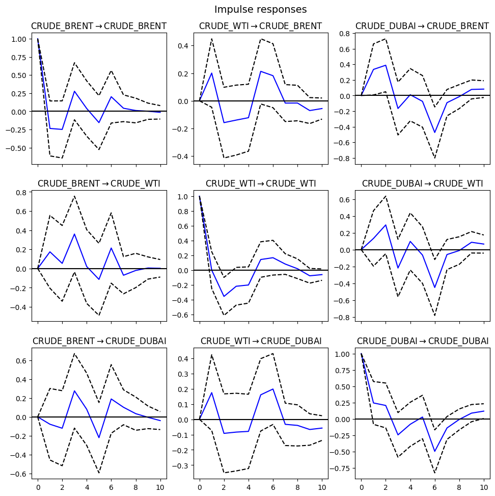

```
Johansen Cointegration Test:
Johansen Trace Stats:
r = 0: statistic = 50.93, crit(95%) = 29.7961
r = 1: statistic = 25.22, crit(95%) = 15.4943
r = 2: statistic = 1.73, crit(95%) = 3.8415

Estimated Cointegration Rank: 2

Fitting VECM Model:
Det. terms outside the coint. relation & lagged endog. parameters for equation CRUDE_BRENT
==================================================================================
                     coef    std err          z      P>|z|      [0.025      0.975]
----------------------------------------------------------------------------------
L1.CRUDE_BRENT    -0.0678      0.216     -0.314      0.754      -0.492       0.356
L1.CRUDE_WTI       0.1102      0.133      0.829      0.407      -0.150       0.371
L1.CRUDE_DUBAI     0.2538      0.177      1.436      0.151      -0.093       0.600
L2.CRUDE_BRENT    -0.1655      0.216     -0.764      0.445      -0.590       0.259
L2.CRUDE_WTI      -0.2470      0.132     -1.877      0.061      -0.505       0.011
L2.CRUDE_DUBAI     0.2847      0.177      1.605      0.108      -0.063       0.632
L3.CRUDE_BRENT     0.3545      0.215      1.646      0.100      -0.068       0.777
L3.CRUDE_WTI      -0.1405      0.132     -1.066      0.286      -0.399       0.118
L3.CRUDE_DUBAI    -0.2244      0.176     -1.272      0.203      -0.570       0.121
L4.CRUDE_BRENT     0.0709      0.208      0.342      0.733      -0.336       0.478
L4.CRUDE_WTI      -0.2302      0.126     -1.828      0.068      -0.477       0.017
L4.CRUDE_DUBAI     0.1151      0.175      0.659      0.510      -0.227       0.458
L5.CRUDE_BRENT     0.0282      0.197      0.143      0.886      -0.357       0.414
L5.CRUDE_WTI       0.1333      0.121      1.098      0.272      -0.105       0.371
L5.CRUDE_DUBAI    -0.1475      0.170     -0.866      0.386      -0.481       0.186
L6.CRUDE_BRENT     0.2883      0.190      1.516      0.130      -0.085       0.661
L6.CRUDE_WTI       0.0572      0.118      0.484      0.628      -0.174       0.289
L6.CRUDE_DUBAI    -0.4433      0.168     -2.640      0.008      -0.772      -0.114
Det. terms outside the coint. relation & lagged endog. parameters for equation CRUDE_WTI
==================================================================================
                     coef    std err          z      P>|z|      [0.025      0.975]
----------------------------------------------------------------------------------
L1.CRUDE_BRENT     0.2009      0.218      0.923      0.356      -0.226       0.627
L1.CRUDE_WTI      -0.0252      0.134     -0.188      0.850      -0.287       0.237
L1.CRUDE_DUBAI     0.1312      0.178      0.738      0.461      -0.217       0.480
L2.CRUDE_BRENT     0.1274      0.218      0.585      0.559      -0.300       0.554
L2.CRUDE_WTI      -0.4358      0.132     -3.292      0.001      -0.695      -0.176
```

[output cut: 53 more lines]

```
          Cointegration relations for loading-coefficients-column 1
==============================================================================
                 coef    std err          z      P>|z|      [0.025      0.975]
------------------------------------------------------------------------------
beta.1         1.0000          0          0      0.000       1.000       1.000
beta.2      5.162e-17          0          0      0.000    5.16e-17    5.16e-17
beta.3        -1.0135      0.006   -169.933      0.000      -1.025      -1.002
          Cointegration relations for loading-coefficients-column 2
==============================================================================
                 coef    std err          z      P>|z|      [0.025      0.975]
------------------------------------------------------------------------------
beta.1     -1.781e-17          0          0      0.000   -1.78e-17   -1.78e-17
beta.2         1.0000          0          0      0.000       1.000       1.000
beta.3        -1.0094      0.014    -70.455      0.000      -1.037      -0.981
==============================================================================
```

```python
do_analysis("Crude Oil", crude_oil_cols)
```

```
===================================
Analyzing Natural Gas Commodities
===================================

ADF (Stationarity) Test:
ADF Test:
NGAS_US: ADF Statistic = -7.619, p = 0.0000 → Stationary
NGAS_EUR: ADF Statistic = -7.527, p = 0.0000 → Stationary
NGAS_JP: ADF Statistic = -6.092, p = 0.0000 → Stationary

Running VAR Model:
 VAR Order Selection (* highlights the minimums)
==================================================
       AIC         BIC         FPE         HQIC
--------------------------------------------------
0       -14.97      -14.94   3.167e-07      -14.96
1       -15.15     -15.06*   2.639e-07      -15.11
2       -15.19      -15.03   2.522e-07      -15.13
3       -15.20      -14.97   2.500e-07      -15.11
4       -15.25      -14.96   2.371e-07     -15.14*
5       -15.24      -14.87   2.404e-07      -15.10
6       -15.24      -14.80   2.419e-07      -15.07
7       -15.22      -14.72   2.449e-07      -15.03
8       -15.23      -14.66   2.433e-07      -15.01
9       -15.24      -14.59   2.419e-07      -14.98
10      -15.24      -14.53   2.403e-07      -14.96
11      -15.26      -14.48   2.369e-07      -14.95
12     -15.28*      -14.43  2.313e-07*      -14.95
--------------------------------------------------
Using AIC-selected lag = 12
  Summary of Regression Results
==================================
Model:                         VAR
Method:                        OLS
Date:           Thu, 24, Jul, 2025
Time:                     13:33:10
--------------------------------------------------------------------
No. of Equations:         3.00000    BIC:                   -14.4325
Nobs:                     569.000    HQIC:                  -14.9493
Log likelihood:           2036.01    FPE:                2.31340e-07
```

[output cut: 121 more lines]

```
L10.NGAS_EUR         0.032606         0.024918            1.309           0.191
L10.NGAS_JP          0.036413         0.044885            0.811           0.417
L11.NGAS_US         -0.006590         0.015926           -0.414           0.679
L11.NGAS_EUR         0.011320         0.025053            0.452           0.651
L11.NGAS_JP         -0.058956         0.043848           -1.345           0.179
L12.NGAS_US          0.013540         0.015982            0.847           0.397
L12.NGAS_EUR         0.004262         0.025129            0.170           0.865
L12.NGAS_JP          0.136496         0.042463            3.214           0.001
===============================================================================

Correlation matrix of residuals
             NGAS_US  NGAS_EUR   NGAS_JP
NGAS_US     1.000000  0.107873  0.133923
NGAS_EUR    0.107873  1.000000  0.246198
NGAS_JP     0.133923  0.246198  1.000000
```

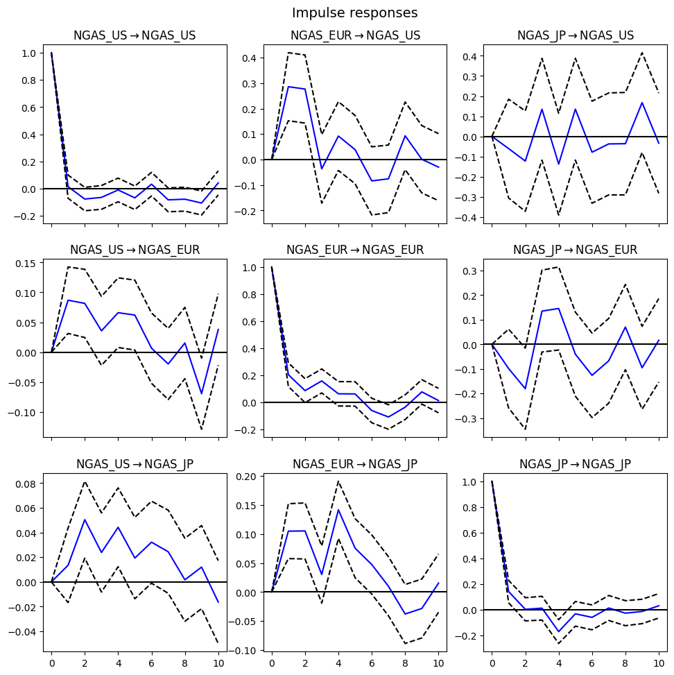

```
Johansen Cointegration Test:
Johansen Trace Stats:
r = 0: statistic = 42.40, crit(95%) = 29.7961
r = 1: statistic = 10.19, crit(95%) = 15.4943
r = 2: statistic = 1.63, crit(95%) = 3.8415

Estimated Cointegration Rank: 1

Fitting VECM Model:
Det. terms outside the coint. relation & lagged endog. parameters for equation NGAS_US
================================================================================
                   coef    std err          z      P>|z|      [0.025      0.975]
--------------------------------------------------------------------------------
L1.NGAS_US       0.0080      0.042      0.190      0.850      -0.075       0.091
L1.NGAS_EUR      0.3022      0.066      4.547      0.000       0.172       0.432
L1.NGAS_JP      -0.0618      0.121     -0.512      0.609      -0.298       0.175
L2.NGAS_US      -0.1071      0.042     -2.537      0.011      -0.190      -0.024
L2.NGAS_EUR      0.2407      0.068      3.520      0.000       0.107       0.375
L2.NGAS_JP      -0.0920      0.122     -0.753      0.452      -0.332       0.148
L3.NGAS_US      -0.1070      0.043     -2.496      0.013      -0.191      -0.023
L3.NGAS_EUR     -0.0466      0.069     -0.677      0.498      -0.181       0.088
L3.NGAS_JP       0.2094      0.122      1.714      0.087      -0.030       0.449
L4.NGAS_US      -0.0405      0.043     -0.951      0.341      -0.124       0.043
L4.NGAS_EUR      0.1117      0.070      1.598      0.110      -0.025       0.249
L4.NGAS_JP      -0.1974      0.122     -1.612      0.107      -0.437       0.043
L5.NGAS_US      -0.1186      0.043     -2.774      0.006      -0.202      -0.035
L5.NGAS_EUR      0.0369      0.070      0.525      0.600      -0.101       0.175
L5.NGAS_JP       0.0790      0.125      0.631      0.528      -0.166       0.324
L6.NGAS_US      -0.0095      0.043     -0.221      0.825      -0.094       0.075
L6.NGAS_EUR     -0.0264      0.070     -0.377      0.706      -0.164       0.111
L6.NGAS_JP      -0.1172      0.125     -0.935      0.350      -0.363       0.129
L7.NGAS_US      -0.1238      0.043     -2.847      0.004      -0.209      -0.039
L7.NGAS_EUR     -0.0248      0.069     -0.358      0.720      -0.161       0.111
L7.NGAS_JP       0.0426      0.125      0.340      0.734      -0.203       0.289
L8.NGAS_US      -0.0722      0.044     -1.659      0.097      -0.157       0.013
L8.NGAS_EUR      0.2093      0.069      3.026      0.002       0.074       0.345
L8.NGAS_JP      -0.0490      0.126     -0.390      0.697      -0.295       0.197
L9.NGAS_US      -0.1498      0.044     -3.435      0.001      -0.235      -0.064
L9.NGAS_EUR      0.0481      0.069      0.697      0.486      -0.087       0.183
L9.NGAS_JP       0.1668      0.122      1.365      0.172      -0.073       0.406
```

[output cut: 97 more lines]

```
------------------------------------------------------------------------------
ec1            0.0042      0.001      4.259      0.000       0.002       0.006
              Loading coefficients (alpha) for equation NGAS_JP
==============================================================================
                 coef    std err          z      P>|z|      [0.025      0.975]
------------------------------------------------------------------------------
ec1           -0.0010      0.001     -1.823      0.068      -0.002    7.49e-05
          Cointegration relations for loading-coefficients-column 1
==============================================================================
                 coef    std err          z      P>|z|      [0.025      0.975]
------------------------------------------------------------------------------
beta.1         1.0000          0          0      0.000       1.000       1.000
beta.2       -14.3707      2.535     -5.670      0.000     -19.338      -9.403
beta.3        11.9888      2.236      5.362      0.000       7.606      16.371
==============================================================================
```

```python
do_analysis("Natural Gas", natural_gas_cols)
```

```
===================================
Analyzing Coal Commodities
===================================

ADF (Stationarity) Test:
ADF Test:
COAL_AUS: ADF Statistic = -6.586, p = 0.0000 → Stationary
COAL_SAFRICA: ADF Statistic = -7.078, p = 0.0000 → Stationary

Running VAR Model:
 VAR Order Selection (* highlights the minimums)
==================================================
       AIC         BIC         FPE         HQIC
--------------------------------------------------
0       -11.33      -11.31   1.205e-05      -11.32
1       -11.40     -11.35*   1.118e-05     -11.38*
2       -11.40      -11.31   1.124e-05      -11.36
3       -11.41      -11.29   1.109e-05      -11.36
4       -11.42      -11.26   1.102e-05      -11.35
5       -11.44      -11.25   1.071e-05      -11.37
6       -11.45      -11.23   1.065e-05      -11.36
7       -11.46      -11.20   1.055e-05      -11.36
8       -11.47      -11.17   1.049e-05      -11.35
9       -11.49      -11.16   1.023e-05      -11.36
10      -11.49      -11.13   1.024e-05      -11.35
11      -11.48      -11.09   1.029e-05      -11.33
12     -11.49*      -11.06  1.020e-05*      -11.32
--------------------------------------------------
Using AIC-selected lag = 12
  Summary of Regression Results
==================================
Model:                         VAR
Method:                        OLS
Date:           Thu, 24, Jul, 2025
Time:                     13:33:11
--------------------------------------------------------------------
No. of Equations:         2.00000    BIC:                   -11.0616
Nobs:                     485.000    HQIC:                  -11.3235
Log likelihood:           1460.67    FPE:                1.02037e-05
AIC:                     -11.4929    Det(Omega_mle):     9.22789e-06
```

[output cut: 52 more lines]

```
L8.COAL_SAFRICA          0.022823         0.067252            0.339           0.734
L9.COAL_AUS              0.126357         0.067617            1.869           0.062
L9.COAL_SAFRICA         -0.000999         0.066564           -0.015           0.988
L10.COAL_AUS            -0.079292         0.068083           -1.165           0.244
L10.COAL_SAFRICA         0.080465         0.066946            1.202           0.229
L11.COAL_AUS             0.076789         0.067836            1.132           0.258
L11.COAL_SAFRICA        -0.110853         0.066741           -1.661           0.097
L12.COAL_AUS            -0.104947         0.066631           -1.575           0.115
L12.COAL_SAFRICA         0.011604         0.066845            0.174           0.862
===================================================================================

Correlation matrix of residuals
                COAL_AUS  COAL_SAFRICA
COAL_AUS        1.000000      0.717841
COAL_SAFRICA    0.717841      1.000000
```

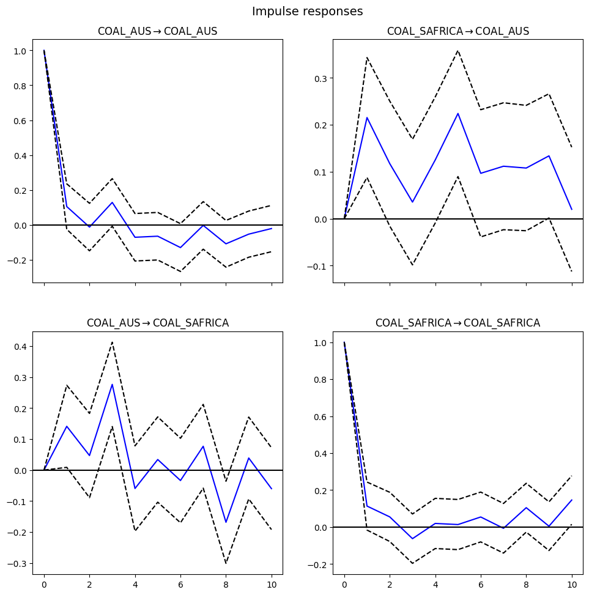

```
Johansen Cointegration Test:
Johansen Trace Stats:
r = 0: statistic = 11.45, crit(95%) = 15.4943
r = 1: statistic = 2.57, crit(95%) = 3.8415

Estimated Cointegration Rank: 0
No cointegration detected; skipping VECM.
```

```python
do_analysis("Coal", coal_cols)
```

## **Metals**

```
===================================
Analyzing Metals Commodities
===================================

ADF (Stationarity) Test:
ADF Test:
GOLD: ADF Statistic = -5.751, p = 0.0000 → Stationary
SILVER: ADF Statistic = -19.601, p = 0.0000 → Stationary
COPPER: ADF Statistic = -17.952, p = 0.0000 → Stationary
ALUMINUM: ADF Statistic = -7.358, p = 0.0000 → Stationary

Running VAR Model:
 VAR Order Selection (* highlights the minimums)
==================================================
       AIC         BIC         FPE         HQIC
--------------------------------------------------
0       -24.01      -23.99   3.721e-11      -24.01
1       -24.26     -24.14*   2.912e-11     -24.21*
2      -24.27*      -24.06  2.874e-11*      -24.19
3       -24.26      -23.95   2.897e-11      -24.14
4       -24.26      -23.85   2.916e-11      -24.10
5       -24.25      -23.74   2.941e-11      -24.06
6       -24.23      -23.63   2.989e-11      -24.00
7       -24.23      -23.53   3.003e-11      -23.96
8       -24.20      -23.41   3.083e-11      -23.90
9       -24.21      -23.32   3.075e-11      -23.86
10      -24.20      -23.21   3.099e-11      -23.82
11      -24.19      -23.11   3.126e-11      -23.77
12      -24.17      -22.99   3.177e-11      -23.72
--------------------------------------------------
Using AIC-selected lag = 2
  Summary of Regression Results
==================================
Model:                         VAR
Method:                        OLS
Date:           Thu, 24, Jul, 2025
Time:                     13:33:12
--------------------------------------------------------------------
No. of Equations:         4.00000    BIC:                   -24.1000
Nobs:                     783.000    HQIC:                  -24.2320
```

[output cut: 54 more lines]

```
L1.SILVER           0.029177         0.033716            0.865           0.387
L1.COPPER           0.055505         0.030267            1.834           0.067
L1.ALUMINUM         0.141546         0.039961            3.542           0.000
L2.GOLD            -0.030449         0.055124           -0.552           0.581
L2.SILVER           0.036090         0.033717            1.070           0.284
L2.COPPER           0.033355         0.030354            1.099           0.272
L2.ALUMINUM        -0.004675         0.039992           -0.117           0.907
==============================================================================

Correlation matrix of residuals
                GOLD    SILVER    COPPER  ALUMINUM
GOLD        1.000000  0.692799  0.247050  0.189586
SILVER      0.692799  1.000000  0.297188  0.263603
COPPER      0.247050  0.297188  1.000000  0.425430
ALUMINUM    0.189586  0.263603  0.425430  1.000000
```

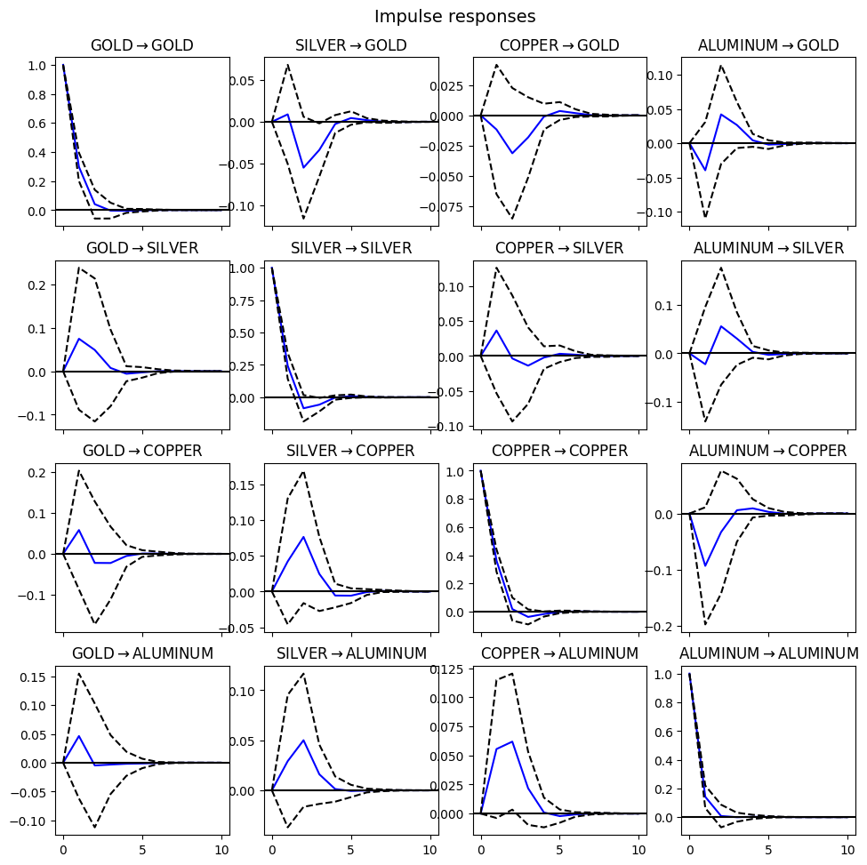

```
Johansen Cointegration Test:
Johansen Trace Stats:
r = 0: statistic = 43.19, crit(95%) = 47.8545
r = 1: statistic = 20.65, crit(95%) = 29.7961
r = 2: statistic = 8.17, crit(95%) = 15.4943
r = 3: statistic = 0.13, crit(95%) = 3.8415

Estimated Cointegration Rank: 0
No cointegration detected; skipping VECM.
```

```python
do_analysis("Metals", metals_cols)
```

## **Agri/Food**

```python
wheat_cols = [
    'WHEAT_US_HRW',
    'WHEAT_US_SRW'
]

sugar_cols = [
    'SUGAR_EU',
    'SUGAR_US',
    'SUGAR_WLD'
]
```

```
===================================
Analyzing Wheat Commodities
===================================

ADF (Stationarity) Test:
ADF Test:
WHEAT_US_HRW: ADF Statistic = -18.674, p = 0.0000 → Stationary
WHEAT_US_SRW: ADF Statistic = -8.815, p = 0.0000 → Stationary

Running VAR Model:
 VAR Order Selection (* highlights the minimums)
==================================================
       AIC         BIC         FPE         HQIC
--------------------------------------------------
0       -12.18      -12.16   5.130e-06      -12.17
1      -12.22*     -12.17*  4.918e-06*     -12.20*
2       -12.21      -12.13   4.973e-06      -12.18
3       -12.20      -12.09   5.035e-06      -12.16
4       -12.20      -12.05   5.048e-06      -12.14
5       -12.20      -12.02   5.037e-06      -12.13
6       -12.20      -11.99   5.039e-06      -12.12
7       -12.20      -11.96   5.019e-06      -12.11
8       -12.20      -11.93   5.011e-06      -12.10
9       -12.22      -11.91   4.943e-06      -12.10
10      -12.21      -11.87   4.999e-06      -12.08
11      -12.20      -11.83   5.036e-06      -12.06
12      -12.19      -11.80   5.064e-06      -12.04
--------------------------------------------------
Using AIC-selected lag = 1
  Summary of Regression Results
==================================
Model:                         VAR
Method:                        OLS
Date:           Thu, 24, Jul, 2025
Time:                     13:33:13
--------------------------------------------------------------------
No. of Equations:         2.00000    BIC:                   -12.1953
Nobs:                     549.000    HQIC:                  -12.2240
Log likelihood:           1808.53    FPE:                4.82180e-06
AIC:                     -12.2424    Det(Omega_mle):     4.76953e-06
```

[output cut: 8 more lines]

```
==================================================================================

Results for equation WHEAT_US_SRW
==================================================================================
                     coefficient       std. error           t-stat            prob
----------------------------------------------------------------------------------
const                   0.000580         0.002776            0.209           0.834
L1.WHEAT_US_HRW         0.074680         0.081647            0.915           0.360
L1.WHEAT_US_SRW         0.103813         0.071537            1.451           0.147
==================================================================================

Correlation matrix of residuals
                WHEAT_US_HRW  WHEAT_US_SRW
WHEAT_US_HRW        1.000000      0.801912
WHEAT_US_SRW        0.801912      1.000000
```

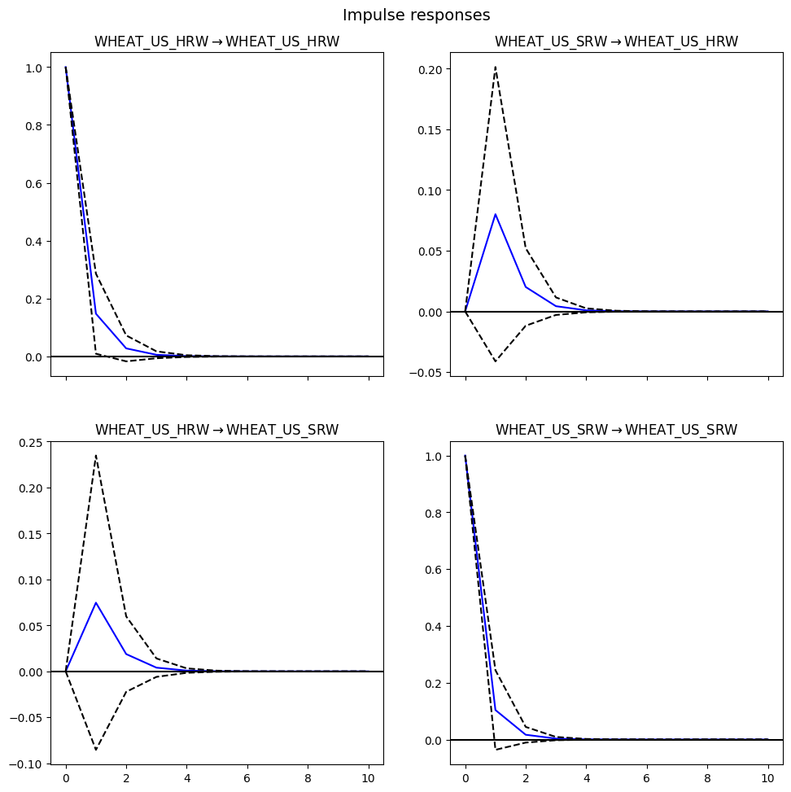

```
Johansen Cointegration Test:
Johansen Trace Stats:
r = 0: statistic = 42.76, crit(95%) = 15.4943
r = 1: statistic = 6.58, crit(95%) = 3.8415

Estimated Cointegration Rank: 2

Fitting VECM Model:
Det. terms outside the coint. relation & lagged endog. parameters for equation WHEAT_US_HRW
===================================================================================
                      coef    std err          z      P>|z|      [0.025      0.975]
-----------------------------------------------------------------------------------
L1.WHEAT_US_HRW     0.1720      0.071      2.439      0.015       0.034       0.310
L1.WHEAT_US_SRW     0.0411      0.063      0.653      0.514      -0.082       0.165
Det. terms outside the coint. relation & lagged endog. parameters for equation WHEAT_US_SRW
===================================================================================
                      coef    std err          z      P>|z|      [0.025      0.975]
-----------------------------------------------------------------------------------
L1.WHEAT_US_HRW     0.0645      0.082      0.786      0.432      -0.096       0.225
L1.WHEAT_US_SRW     0.1204      0.073      1.643      0.100      -0.023       0.264
            Loading coefficients (alpha) for equation WHEAT_US_HRW
==============================================================================
                 coef    std err          z      P>|z|      [0.025      0.975]
------------------------------------------------------------------------------
ec1           -0.0736      0.027     -2.681      0.007      -0.127      -0.020
ec2            0.0749      0.028      2.684      0.007       0.020       0.130
            Loading coefficients (alpha) for equation WHEAT_US_SRW
==============================================================================
                 coef    std err          z      P>|z|      [0.025      0.975]
------------------------------------------------------------------------------
ec1            0.0314      0.032      0.981      0.326      -0.031       0.094
ec2           -0.0318      0.032     -0.981      0.327      -0.095       0.032
          Cointegration relations for loading-coefficients-column 1
==============================================================================
                 coef    std err          z      P>|z|      [0.025      0.975]
------------------------------------------------------------------------------
beta.1         1.0000          0          0      0.000       1.000       1.000
beta.2     -2.145e-16          0          0      0.000   -2.15e-16   -2.15e-16
          Cointegration relations for loading-coefficients-column 2
==============================================================================
                 coef    std err          z      P>|z|      [0.025      0.975]
------------------------------------------------------------------------------
beta.1      2.186e-16          0          0      0.000    2.19e-16    2.19e-16
beta.2         1.0000          0          0      0.000       1.000       1.000
==============================================================================
```

```python
do_analysis("Wheat", wheat_cols)
```

```
===================================
Analyzing Sugar Commodities
===================================

ADF (Stationarity) Test:
ADF Test:
SUGAR_EU: ADF Statistic = -7.697, p = 0.0000 → Stationary
SUGAR_US: ADF Statistic = -8.845, p = 0.0000 → Stationary
SUGAR_WLD: ADF Statistic = -14.277, p = 0.0000 → Stationary

Running VAR Model:
 VAR Order Selection (* highlights the minimums)
==================================================
       AIC         BIC         FPE         HQIC
--------------------------------------------------
0       -16.77      -16.75   5.202e-08      -16.76
1       -16.94     -16.86*   4.415e-08      -16.91
2       -16.99      -16.86   4.201e-08     -16.94*
3       -16.98      -16.80   4.218e-08      -16.91
4       -17.00      -16.76   4.153e-08      -16.91
5       -17.04      -16.75   3.968e-08      -16.93
6       -17.03      -16.68   4.029e-08      -16.90
7      -17.05*      -16.66  3.930e-08*      -16.90
8       -17.05      -16.59   3.954e-08      -16.87
9       -17.03      -16.53   4.003e-08      -16.84
10      -17.04      -16.48   3.992e-08      -16.82
11      -17.03      -16.42   3.999e-08      -16.80
12      -17.04      -16.37   3.988e-08      -16.78
--------------------------------------------------
Using AIC-selected lag = 7
  Summary of Regression Results
==================================
Model:                         VAR
Method:                        OLS
Date:           Thu, 24, Jul, 2025
Time:                     13:33:14
--------------------------------------------------------------------
No. of Equations:         3.00000    BIC:                   -16.6524
Nobs:                     778.000    HQIC:                  -16.8955
Log likelihood:           3385.67    FPE:                3.94813e-08
```

[output cut: 76 more lines]

```
L5.SUGAR_US          0.169758         0.078605            2.160           0.031
L5.SUGAR_WLD        -0.064394         0.044384           -1.451           0.147
L6.SUGAR_EU         -0.014861         0.076770           -0.194           0.847
L6.SUGAR_US         -0.085112         0.078840           -1.080           0.280
L6.SUGAR_WLD         0.075317         0.044341            1.699           0.089
L7.SUGAR_EU          0.139866         0.074913            1.867           0.062
L7.SUGAR_US         -0.114762         0.076542           -1.499           0.134
L7.SUGAR_WLD        -0.022145         0.042800           -0.517           0.605
===============================================================================

Correlation matrix of residuals
             SUGAR_EU  SUGAR_US  SUGAR_WLD
SUGAR_EU     1.000000  0.094632   0.119221
SUGAR_US     0.094632  1.000000   0.515957
SUGAR_WLD    0.119221  0.515957   1.000000
```

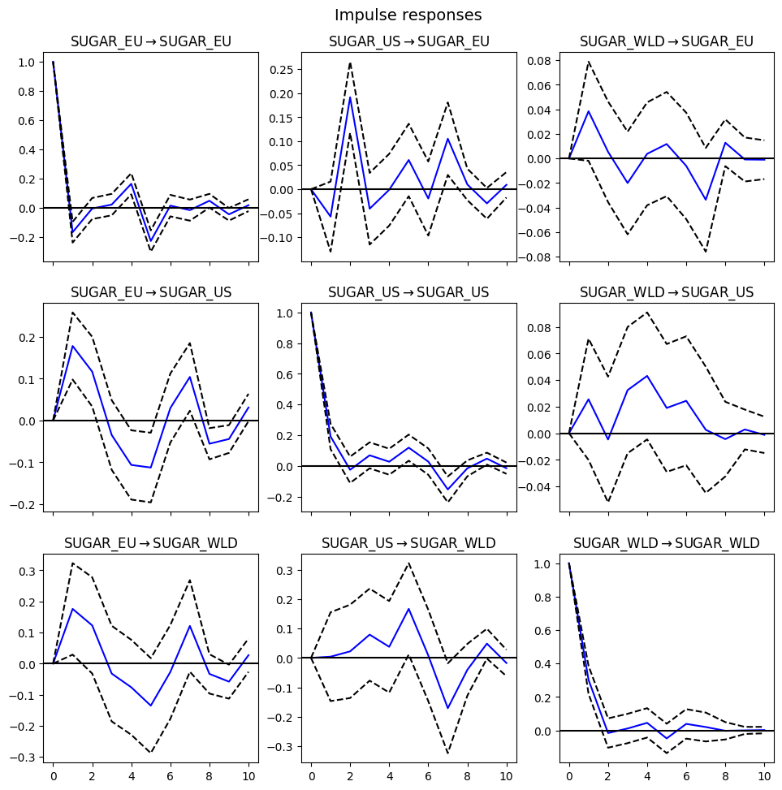

```
Johansen Cointegration Test:
Johansen Trace Stats:
r = 0: statistic = 23.88, crit(95%) = 29.7961
r = 1: statistic = 9.84, crit(95%) = 15.4943
r = 2: statistic = 3.14, crit(95%) = 3.8415

Estimated Cointegration Rank: 0
No cointegration detected; skipping VECM.
```

```python
do_analysis("Sugar", sugar_cols)
```